# Part I - Loan Dataset analysis and exploration

## Multivariate Exploration

> I want to explore here the relation between original amount, estimated return, debt to income ration with percentage funded and the number of investors

```python
def Mscatter(data,x,y,c,til,lim):
  plt.figure(figsize = [10, 8])
  g = sb.FacetGrid(data = data, hue = c, height = 5, palette='viridis')
  g.map(plt.scatter, x, y,alpha  = 0.5)
  g.add_legend()
  plt.xlim(lim)
  plt.title(til)
  plt.show()
```

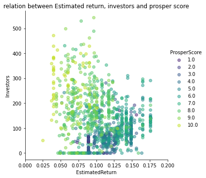

```python
Mscatter(data =merged_sample , x = 'EstimatedReturn', y = 'Investors',til='relation between Estimated return, investors and prosper score',c='ProsperScore', lim=(0,0.2))
```

We can see here that the lower the risk the lower the estimated return and we can see that the higher risk is the lower the number of investors

[figure not shown]

```python
Mscatter(data =merged_sample, x = 'DebtToIncomeRatio', y = 'Investors',til='Debt to income ratio, Investors and prosper score',c='ProsperScore',lim=(0,0.2));
```

In this graph we cannot see a clear relation between the number of investors and Debt ro income ration grouped by prosper score

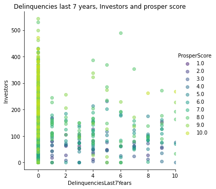

```python
Mscatter(data =merged_sample, x = 'DelinquenciesLast7Years', y = 'Investors',til='Delinquencies last 7 years, Investors and prosper score',c='ProsperScore',lim=(-1,10));
```

We can see a correlation between the number of delinquencies and the prosper score, normaly the lower the delinquencie the lower the risk and the higher the number of investors willing to invest

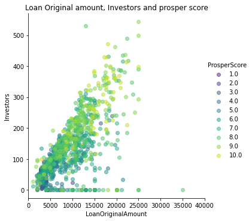

```python
Mscatter(data =merged_sample, x = 'LoanOriginalAmount', y = 'Investors',til='Loan Original amount, Investors and prosper score',c='ProsperScore',lim=(0,40000));
```

We can see that the different prosper scores are not concentred on a specific spot.

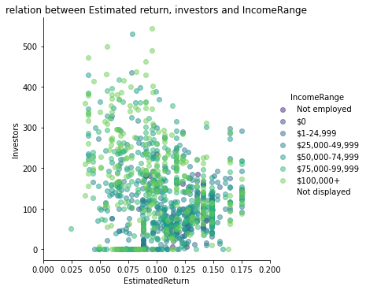

```python
Mscatter(data =merged_sample , x = 'EstimatedReturn', y = 'Investors',til='relation between Estimated return, investors and IncomeRange',c='IncomeRange', lim=(0,0.2))
```

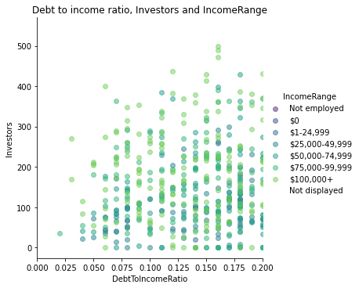

```python
Mscatter(data =merged_sample, x = 'DebtToIncomeRatio', y = 'Investors',til='Debt to income ratio, Investors and IncomeRange',c='IncomeRange',lim=(0,0.2));
```

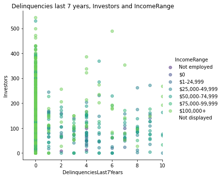

```python
Mscatter(data =merged_sample, x = 'DelinquenciesLast7Years', y = 'Investors',til='Delinquencies last 7 years, Investors and IncomeRange',c='IncomeRange',lim=(-1,10));
```

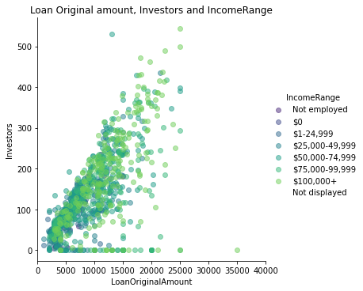

```python
Mscatter(data =merged_sample, x = 'LoanOriginalAmount', y = 'Investors',til='Loan Original amount, Investors and IncomeRange',c='IncomeRange',lim=(0,40000));
```

we can see the same patter repeated with the income range as a third variable, we can assume that the the more the income range is the lower the risk

### Talk about some of the relation you observed in this part of the investigation. Were there features that strengthened each other in terms of looking at your feature(s) of interest?

> I found that investors are more interested in loans with low Estimated returns but in the same time they have a low risk, the seconde observation I found that there is a positive relation between the income range and the prosper risk that means that the higher the income range the lower is the risk. finally i found that the higher the income range the lower the delinquencies is.

## Conclusions

> I choosed the Loan dataset to answer the questions about what impact the percentage funded of the loan and the number of investors. Unfortunately the majority of loans was 100% funded that prented us to find any correlation between the percentFunded and the other variables. In other side the number of investors was more exploitable. we found some positive relations with the income range, the prosper risk, and the original amount of the loan as expected.